# Geom Bar in R

Nicole Fimmen

2018-07-26

https://www.sharpsightlabs.com/blog/ultimate-guide-bar-chart-geom_bar/

# Geom Bar with ggplot2

We’re going to practice the basic bar chart with ggplot2. We will be using the data set Arthritis from the vcd package.

Full disclosure, I’m doing the exact excercise laid out on Sharp Sight Data https://www.sharpsightlabs.com/blog/ultimate-guide-bar-chart-geom_bar/.

Make sure you have the vcd library downloaded. Here are the libraries we will be using.

```r
library(tidyverse)
library(forcats)
library(vcd)
```

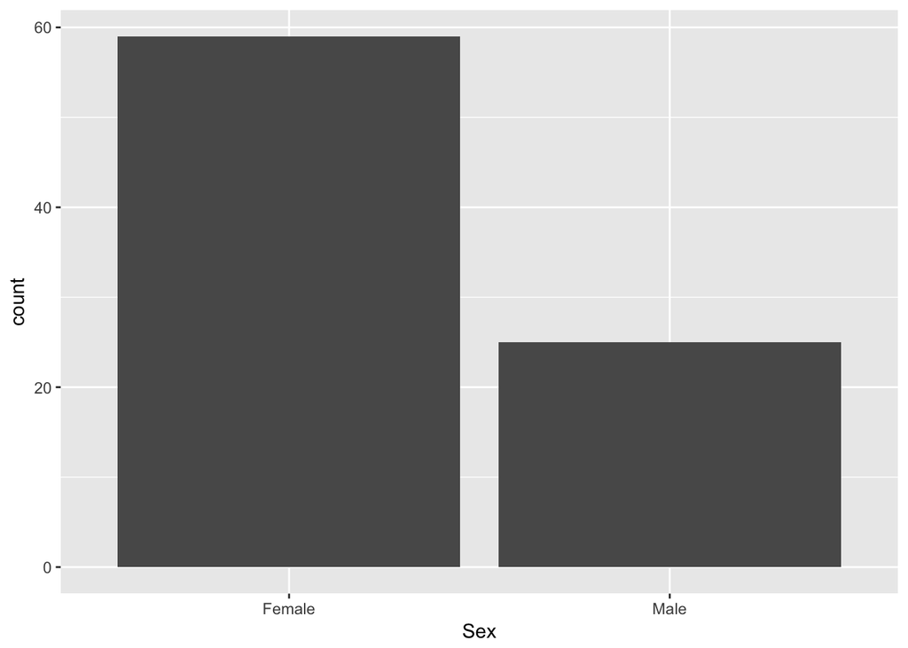

```r
ggplot(data = Arthritis, aes(x = Sex)) +
  geom_bar()
```

Let’s checkout what all is in the Athritis dataframe. It is very important to inspect our data to understand what we are working with. Using the head function will do what it sounds like and gives you the first few rows of the data.

Glimpse goes into how many variables and observations there are.

```r
head(Arthritis)
```

```
##   ID Treatment  Sex Age Improved
## 1 57   Treated Male  27     Some
## 2 46   Treated Male  29     None
## 3 77   Treated Male  30     None
## 4 17   Treated Male  32   Marked
## 5 36   Treated Male  46   Marked
## 6 23   Treated Male  58   Marked
```

```r
glimpse(Arthritis)
## Observations: 84
## Variables: 5
## $ ID        <int> 57, 46, 77, 17, 36, 23, 75, 39, 33, 55, 30, 5, 63, 8...
## $ Treatment <fct> Treated, Treated, Treated, Treated, Treated, Treated...
## $ Sex       <fct> Male, Male, Male, Male, Male, Male, Male, Male, Male...
## $ Age       <int> 27, 29, 30, 32, 46, 58, 59, 59, 63, 63, 64, 64, 69, ...
## $ Improved  <ord> Some, None, None, Marked, Marked, Marked, None, Mark...
```

# ggplot Building Blocks

A good way to think of ggplot is like building blocks. It follows a systemtic flow each time you create a visualization.

1. function - ggplot()
2. data parameter and this time it was “Arthritis” dataframe.
3. function - aes() this maps the variable to the x axis.
4. geom - this is the object that we’r drawing, whether a bar graph, scatterplot or whatever.

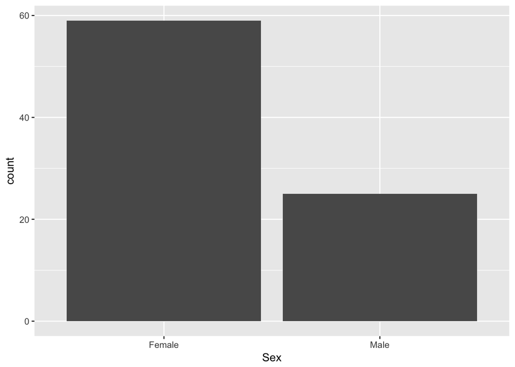

```r
ggplot(data = Arthritis, aes(x = Sex)) +
  geom_bar()
```

where i left off …. https://www.sharpsightlabs.com/blog/ultimate-guide-bar-chart-geom_bar/ HOW TO MODIFY A SIMPLE GGPLOT BAR CHART

# Including Plots

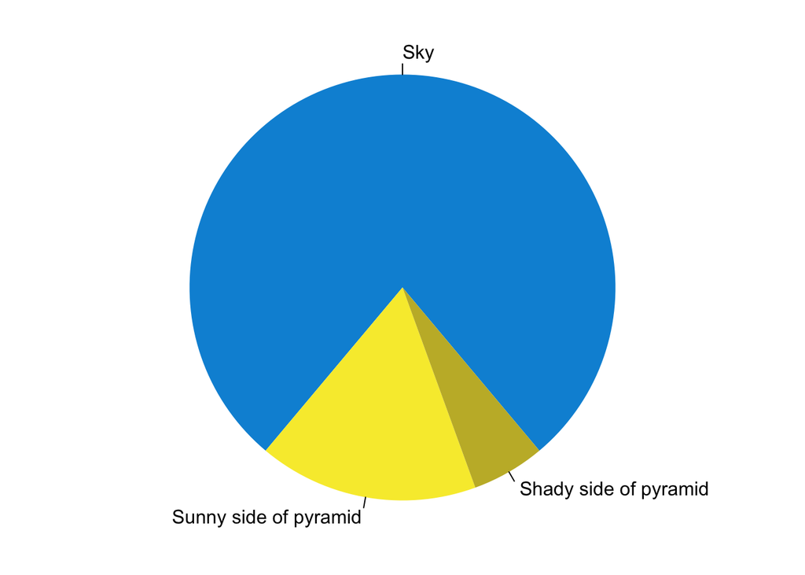

A fancy pie chart.

```r
par(mar = c(0, 1, 0, 1))
pie(
  c(280, 60, 20),
  c('Sky', 'Sunny side of pyramid', 'Shady side of pyramid'),
  col = c('#0292D8', '#F7EA39', '#C4B632'),
  init.angle = -50, border = NA
)
```